# Regression Diagnostics in R

# 1 Overview

Regression in general looking at variations

# 2 Data Description

will be using the very sexy abalone dataset from UCI Machine Learning repository

```r
# load libraries
library(ggplot2) #ggplot for better looking graphics
library(ISLR) #datasets from ISLR
library(car) #regression tools
library(AppliedPredictiveModeling) #UCI datasets
library(corrplot) #for correlations plot
# load the abalone data
data("abalone")
abaDat <- abalone
# apply column names
colnames(abaDat) <-c("sex","len","diam","h","ww","sw","vw","sh","rings")
# add 1.5 to get the predict variable
abaDat$age <- abaDat$rings+1.5
# look at the dimensions of the data
dim(abaDat)
```

```
[1] 4177   10
```

note on package of appliedpredict… because didn’t want to link to my own dataset

# 3 Correlation

```r
# get spearman correlations
scor <- cor(abaDat[,2:ncol(abaDat)],method="spearman")
scor
```

```
            len      diam         h        ww        sw        vw        sh
len   1.0000000 0.9833190 0.8882060 0.9726329 0.9568303 0.9526577 0.9479264
diam  0.9833190 1.0000000 0.8957053 0.9713244 0.9504722 0.9483906 0.9541488
h     0.8882060 0.8957053 1.0000000 0.9159848 0.8741960 0.9005869 0.9212243
ww    0.9726329 0.9713244 0.9159848 1.0000000 0.9770596 0.9752517 0.9694259
sw    0.9568303 0.9504722 0.8741960 0.9770596 1.0000000 0.9476354 0.9177305
vw    0.9526577 0.9483906 0.9005869 0.9752517 0.9476354 1.0000000 0.9381434
sh    0.9479264 0.9541488 0.9212243 0.9694259 0.9177305 0.9381434 1.0000000
rings 0.6043853 0.6228950 0.6577164 0.6308320 0.5394200 0.6143438 0.6924746
age   0.6043853 0.6228950 0.6577164 0.6308320 0.5394200 0.6143438 0.6924746
          rings       age
len   0.6043853 0.6043853
diam  0.6228950 0.6228950
h     0.6577164 0.6577164
ww    0.6308320 0.6308320
sw    0.5394200 0.5394200
vw    0.6143438 0.6143438
sh    0.6924746 0.6924746
rings 1.0000000 1.0000000
age   1.0000000 1.0000000
```

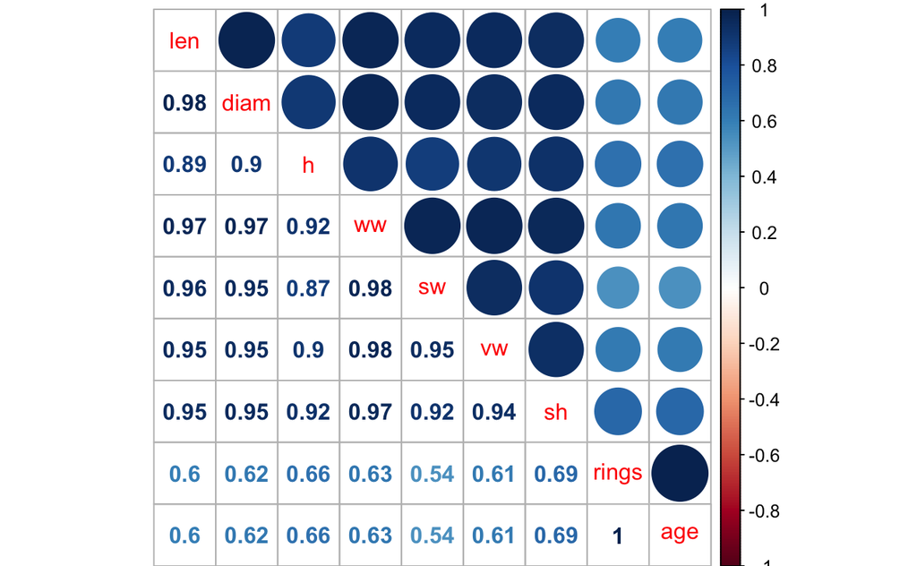

```r
# visualize
corrplot.mixed(scor)
```

```r
# get pearson correlations
pcor <- cor(abaDat[,2:ncol(abaDat)],method="pearson")
pcor
```

```
            len      diam         h        ww        sw        vw        sh
len   1.0000000 0.9868116 0.8275536 0.9252612 0.8979137 0.9030177 0.8977056
diam  0.9868116 1.0000000 0.8336837 0.9254521 0.8931625 0.8997244 0.9053298
h     0.8275536 0.8336837 1.0000000 0.8192208 0.7749723 0.7983193 0.8173380
ww    0.9252612 0.9254521 0.8192208 1.0000000 0.9694055 0.9663751 0.9553554
sw    0.8979137 0.8931625 0.7749723 0.9694055 1.0000000 0.9319613 0.8826171
vw    0.9030177 0.8997244 0.7983193 0.9663751 0.9319613 1.0000000 0.9076563
sh    0.8977056 0.9053298 0.8173380 0.9553554 0.8826171 0.9076563 1.0000000
rings 0.5567196 0.5746599 0.5574673 0.5403897 0.4208837 0.5038192 0.6275740
age   0.5567196 0.5746599 0.5574673 0.5403897 0.4208837 0.5038192 0.6275740
          rings       age
len   0.5567196 0.5567196
diam  0.5746599 0.5746599
h     0.5574673 0.5574673
ww    0.5403897 0.5403897
sw    0.4208837 0.4208837
vw    0.5038192 0.5038192
sh    0.6275740 0.6275740
rings 1.0000000 1.0000000
age   1.0000000 1.0000000
```

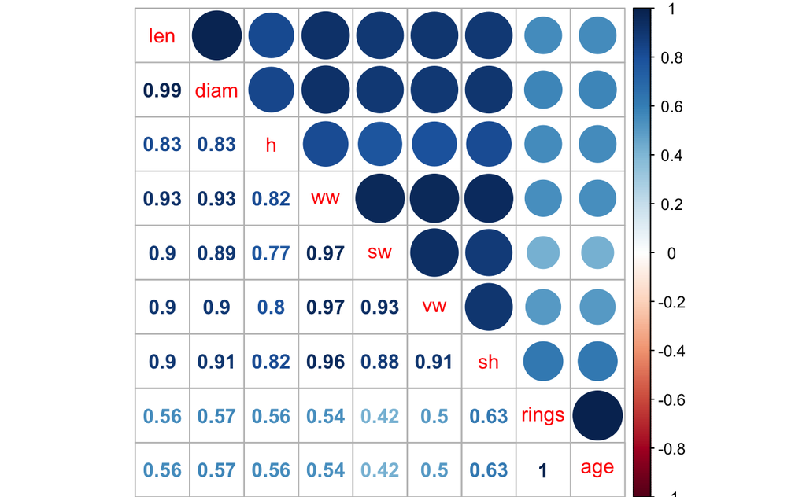

```r
# visualize
corrplot.mixed(pcor)
```

# 4 Regression

```r
# regress age on shell weight
fit <- lm(age~sh,abaDat)
# summary of results1
summary(fit)
```

```
Call:
lm(formula = age ~ sh, data = abaDat)

Residuals:
    Min      1Q  Median      3Q     Max
-5.9830 -1.6005 -0.5843  0.9390 15.6334

Coefficients:
            Estimate Std. Error t value Pr(>|t|)
(Intercept)  7.96212    0.07715  103.21   <2e-16 ***
sh          14.53568    0.27908   52.08   <2e-16 ***
---
Signif. codes:  0 ‘***’ 0.001 ‘**’ 0.01 ‘*’ 0.05 ‘.’ 0.1 ‘ ’ 1

Residual standard error: 2.51 on 4175 degrees of freedom
Multiple R-squared:  0.3938,    Adjusted R-squared:  0.3937
F-statistic:  2713 on 1 and 4175 DF,  p-value: < 2.2e-16
```

```r
r2<-round(summary(fit)$r.squared,2)
rse<-round(summary(fit)$sigma,2)
```

The $R^2$ tells us that shell weight explains about 40% of the variation in the age variable. Given that the coefficients in the model have p-values approximating zero, we can say that this is a statistically significant predictor.

The $R^2$ is 0.39 and the RSE is 2.51.

$\hat{\beta}_1$ tells us that for every unit increase in shell weight, age increases by 14 units. The intercept is the average value of age if shell weight is equal to zero. However, neither age nor shell can equal zero so the intercept is meaningless

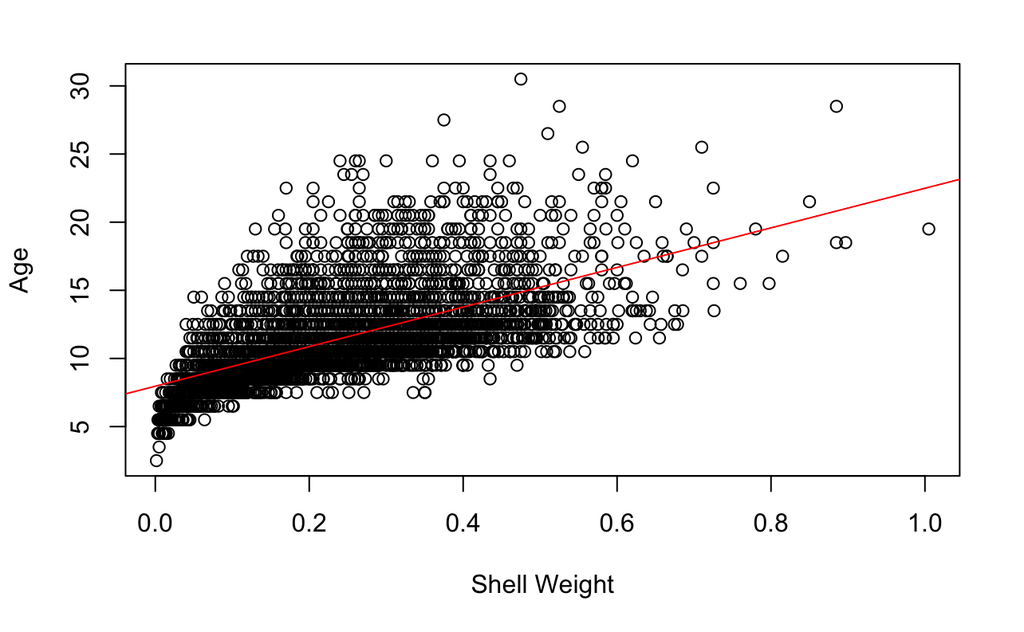

```r
# scatterplot with fitted line
plot(abaDat$sh,abaDat$age,xlab="Shell Weight",ylab="Age")
abline(fit,col="red")
```

# 5 Diagnostics

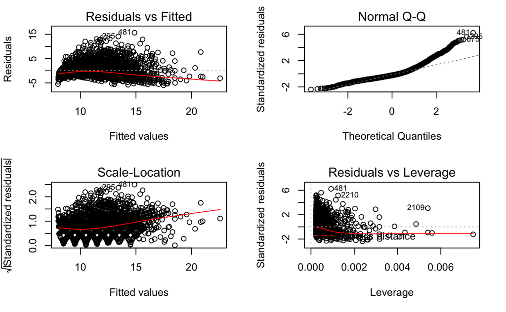

```r
# diagnostic plots
par(mfrow=c(2,2))
plot(fit)
```

- The fitted line plot and the residuals vs fitted values plot both suggest a nonlinearity in the relationship between the two variables. The QQ plot also shows us that the residuals violate the assumption of normally distributed errors. The Scale Location plot suggests there is heteroskadasticity while the leverage plot indicates there are a few levered points of relatively small magnitude.

# 6 Intervals

```r
# confidence intervals
confint(fit)
```

```
                2.5 %    97.5 %
(Intercept)  7.810869  8.113365
sh          13.988525 15.082825
```

```r
# new values
new.vals <- data.frame(sh=c(0.1,0.2,0.3))
# confidence intervals for new values
predict(fit, newdata=new.vals, interval="confidence")
```

```
        fit       lwr       upr
1  9.415684  9.308121  9.523247
2 10.869252 10.790188 10.948315
3 12.322819 12.239634 12.406005
```

```r
# prediction intervals for new values
predict(fit, newdata=new.vals, interva="prediction")
```

```
        fit      lwr      upr
1  9.415684 4.492593 14.33878
2 10.869252 5.946701 15.79180
3 12.322819 7.400201 17.24544
```

- The confidence interval for parameters and predictions give us a range of values that, if the experiment were repeated 100 times, 95 of those times the parameter/prediction would fall within that range.
- Confidence intervals are centered around averages while prediction intervals are centered around a particular instance of a variable.
- Prediction intervals are wider because their standard error is larger; it is larger because individual variations in the data are larger than the average variations of all variable observations.

# 7 Transformation

```r
# log transformed fit
fit_log<-lm(log(age)~log(sh),abaDat)
# summary
summary(fit_log)
```

```
Call:
lm(formula = log(age) ~ log(sh), data = abaDat)

Residuals:
     Min       1Q   Median       3Q      Max
-0.53640 -0.13059 -0.03779  0.09806  0.79228

Coefficients:
            Estimate Std. Error t value Pr(>|t|)
(Intercept) 2.807031   0.006642  422.62   <2e-16 ***
log(sh)     0.243920   0.003574   68.25   <2e-16 ***
---
Signif. codes:  0 ‘***’ 0.001 ‘**’ 0.01 ‘*’ 0.05 ‘.’ 0.1 ‘ ’ 1

Residual standard error: 0.1874 on 4175 degrees of freedom
Multiple R-squared:  0.5273,    Adjusted R-squared:  0.5272
F-statistic:  4657 on 1 and 4175 DF,  p-value: < 2.2e-16
```

```r
# get r2
r2_log <- round(summary(fit_log)$r.squared,2)
```

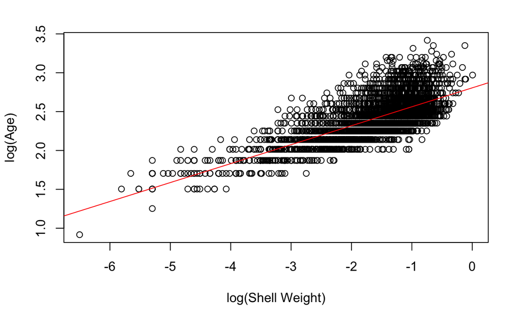

```r
# scatterplot with fitted line
plot(log(abaDat$sh),log(abaDat$age),xlab="log(Shell Weight)",ylab="log(Age)")
abline(fit_log,col="red")
```

There appears to be a better linear fit, however, some nonlinearity still appears as the log of shell weight increases.

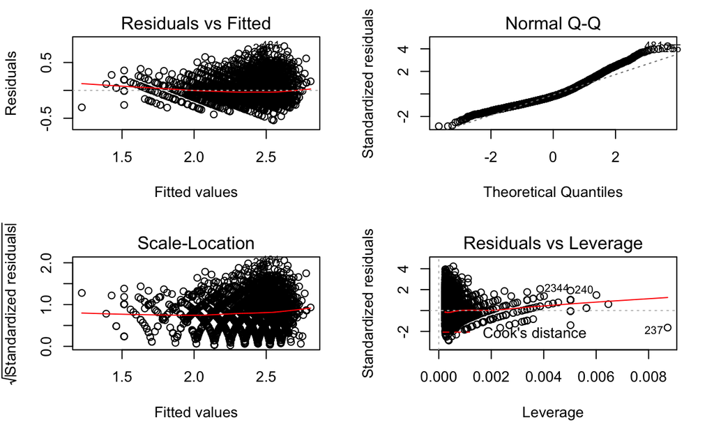

```r
# diagnostic plots
par(mfrow=c(2,2))
plot(fit_log)
```

The residuals seem to be more randomly distributed above and below the line, however, heteroskedasticity is still in place. The QQ plot also tells us that the residuals seem to be more closely distributed normally.

```r
# model
log_mfit<-lm(log(age)~log(sh)+log(sw),abaDat)
# summary
summary(log_mfit)
```

```
Call:
lm(formula = log(age) ~ log(sh) + log(sw), data = abaDat)

Residuals:
     Min       1Q   Median       3Q      Max
-1.18739 -0.11470 -0.02266  0.09106  0.79285

Coefficients:
             Estimate Std. Error t value Pr(>|t|)
(Intercept)  2.926705   0.007407  395.14   <2e-16 ***
log(sh)      0.544297   0.011098   49.05   <2e-16 ***
log(sw)     -0.296300   0.010460  -28.33   <2e-16 ***
---
Signif. codes:  0 ‘***’ 0.001 ‘**’ 0.01 ‘*’ 0.05 ‘.’ 0.1 ‘ ’ 1

Residual standard error: 0.1717 on 4174 degrees of freedom
Multiple R-squared:  0.6035,    Adjusted R-squared:  0.6033
F-statistic:  3177 on 2 and 4174 DF,  p-value: < 2.2e-16
```

```r
r2_mfit<-round(summary(log_mfit)$r.squared,2)
# confidence intervals
confint(log_mfit)
```

```
                 2.5 %     97.5 %
(Intercept)  2.9121840  2.9412263
log(sh)      0.5225392  0.5660546
log(sw)     -0.3168073 -0.2757926
```

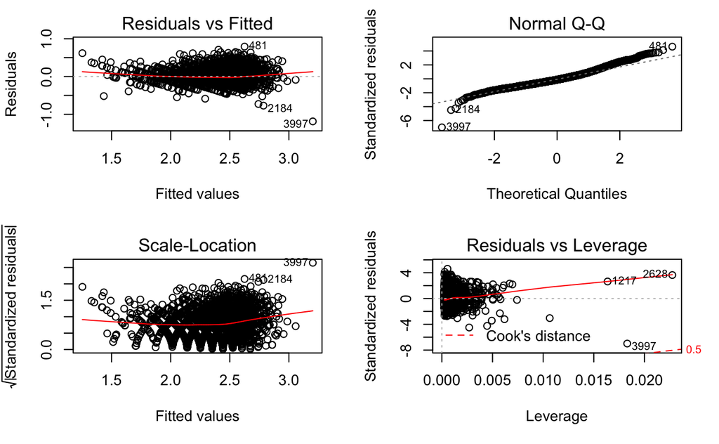

```r
# diagnostic plots
par(mfrow=c(2,2))
plot(log_mfit)
```

Adding the log of shucked weight helps with the predictive power of the model. The $R^2$ increases from 0.53 to 0.6 and all there $\hat{\beta}$s are significant with p-values approaching zero. While there are a few leverage points, the residuals seem to be less heteroskedastic, have less patterns in their distributions over fitted values, and have a more normal distribution. The biggest downside of adding log of shucked weight is that interpreting OLS models with multiple predictors is not as straight forward as interpreting models with only one predictor.